# ENGSCI 211 – 2020 S1 EXAM – Section B: Data Analysis

NAME: Henry Gann – UoA Username: 501 429 763

# Question 10 (6 marks)

**Q10(a) (2 marks)**: Consider the following scenario:

A flour factory would like to determine whether their flour bag filling machines require recalibration. A sample of 1000 bags of 1kg flour was weighed, and a one-sample $t$-test with the null hypothesis that the average weight of the flour bags is 1kg gave a $p$-value greater than 0.05.

However, the 1000 bags were made by 50 identical machines, where each machine produced 20 bags. When separate one-sample $t$-tests were conducted on the average weight of the flour bags from *each machine* being 1kg, two of the tests returned a $p$-value less than 0.05.

The maintenance company requires that either all 50 machines are recalibrated, or none of them are.

Give an explanation for this result. Based on your interpretation, give a recommendation as to whether the flour factory should recalibrate their machines.

2 machines in 50 produced a notable $p$-value. Our samples are also taken with a 95% confidence interval, which means that we could expect 5 in 100 machines to produce a notable $p$-value, however, based on our sample, only 2 in 50 machines did. This means that the machines are likely accurate and will not need recalibration. The explanation would be that about 5% of the time, the sample as a whole would produce a $p$-value less than 0.05, so this was likely conincidence.

**Q10(b)** Consider the following R output comparing the incomes of people in two cities `A` and `B`.

```
> t.test(log(income) ~ city, data = incomeExam.df, var.equal = TRUE)

        Two Sample t-test

data:  log(income) by city
t = -3.8316, df = 58, p-value = 0.0003154
alternative hypothesis: true difference in means is not equal to 0
95 percent confidence interval:
 -2.7740082 -0.8701964
sample estimates:
mean in group A mean in group B
       10.37033        12.19243

> exp(t.test(log(income) ~ city, data = incomeExam.df,
             var.equal = TRUE)$conf.int)
[1] 0.06241135 0.41886929
```

**Q10(b) i) (2 marks)**: With respect to the relevant null hypothesis, give an interpretation of the $p$-value of the test conducted.

The $p$-value is statistically significant as it is less than 0.05. It indicates the the true difference in logged means is likely not equal to 0.

**Q10(b) ii) (1 mark)**: Interpret the confidence interval produced.

The income in city A is between 0.062 and 0.419 times the income in city B.

**Q10(c) (1 mark)**: A particular simple linear regression model gave a $R^2$ statistic of 100%. Describe what this means in terms of the fitted line relative to the data points.

It means that the model explains all variation in the data. It does not necessarily mean that the straight line passes through every data point, but it may.

**WARNING: Marks will be deducted for writing reports that are not specifically asked for in the question parts. Please keep your answers concise. Do NOT do a brain dump.**

# Question 11 (7 marks)

Question 11 requires you to conduct an analysis in RStudio or R on the dataset described below. The dataset is available on Canvas as the file *deflection.txt*.

We are interested in determining the quality of a type of road surface pavement by determining the relationship between temperature and the pavement deflection.

The file *deflection.txt* contains the following variables:

`Temp` : Temperature, in $^\circ$F.  
`Deflection` : Deflection of road surface, in inches.

**Q11(a) (3 marks)**: Conduct the appropriate analysis in R to answer the question. Your analysis should contain the following, similar to the Case Studies and Assignment:

- exploratory analysis
- checking modelling assumptions
- appropriate statistical inference, i.e. hypothesis tests and / or confidence intervals

You are **NOT** required to write comments on your R output – there are no marks allocated for comments.

```r
library(s20x)
deflection.df = read.table("deflection.txt", header = TRUE)
head(deflection.df)
```

```
##   Temp Deflection
## 1 70.0      0.621
## 2 77.0      0.657
## 3 72.1      0.640
## 4 72.8      0.623
## 5 78.3      0.661
## 6 74.5      0.641
```

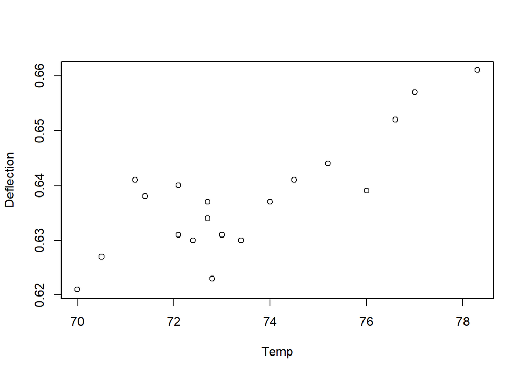

```r
plot(Deflection ~ Temp, data = deflection.df)
```

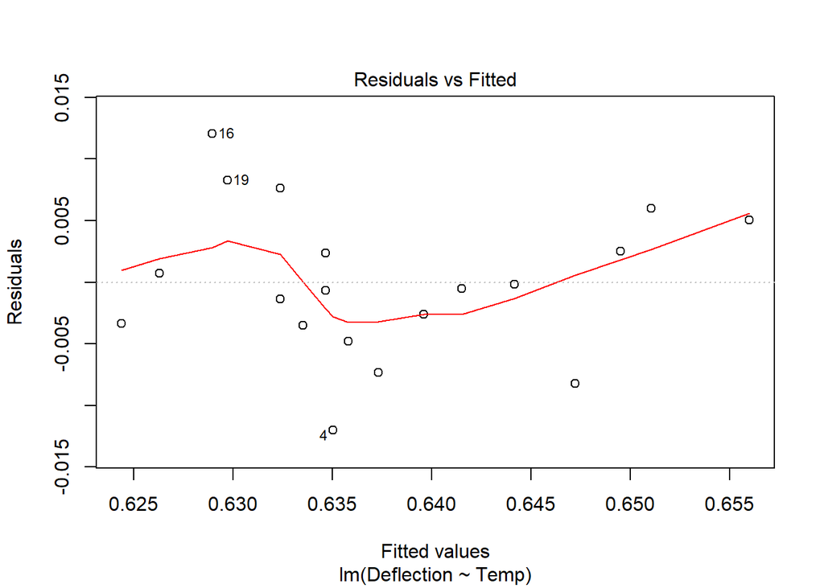

```r
deflection.fit = lm(Deflection ~ Temp, data = deflection.df)
plot(deflection.fit, which = 1)
```

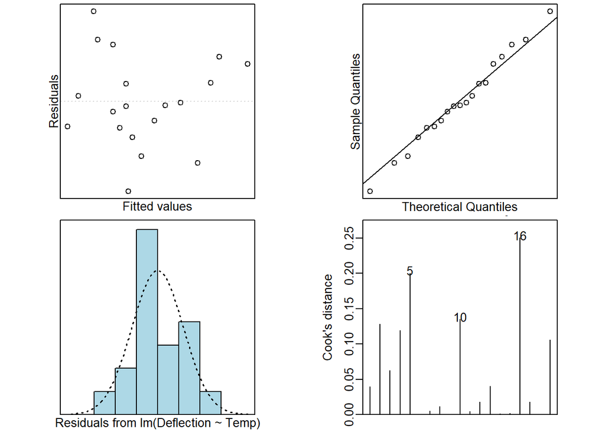

```r
modcheck(deflection.fit)
```

```r
summary(deflection.fit)
```

```
##
## Call:
## lm(formula = Deflection ~ Temp, data = deflection.df)
##
## Residuals:
##        Min         1Q     Median         3Q        Max
## -0.0120347 -0.0034444 -0.0005056  0.0037655  0.0120556
##
## Coefficients:
##              Estimate Std. Error t value Pr(>|t|)
## (Intercept) 0.3579274  0.0476671   7.509 8.55e-07 ***
## Temp        0.0038064  0.0006485   5.869 1.86e-05 ***
## ---
## Signif. codes:  0 '***' 0.001 '**' 0.01 '*' 0.05 '.' 0.1 ' ' 1
##
## Residual standard error: 0.006267 on 17 degrees of freedom
## Multiple R-squared:  0.6696, Adjusted R-squared:  0.6501
## F-statistic: 34.45 on 1 and 17 DF,  p-value: 1.857e-05
```

```r
confint(deflection.fit)
```

```
##                  2.5 %      97.5 %
## (Intercept) 0.25735854 0.458496233
## Temp        0.00243817 0.005174667
```

**Q11(b) (3 marks)**: Write a brief **Executive Summary** explaining the findings of the analysis that you have conducted.

It was of interest to determine the quality of a type of road surface pavement by determining the relationship between temperature and the pavement deflection.

We find that the higher the temperature, the greater the deflection of the pavement.

We estimate that if the temperature was $0^\circ$F then the deflection would be between 0.25 and 0.46 and for every additional $^\circ$F, the deflection increases between 0.0024 and 0.0052.

Our model explains 67% of the variation in deflection as a result of the temperature. This means that it is not a suitable model for predictions.

**Q11(c) (1 mark)**: Use the appropriate R command(s) to give an estimate for the average roadway pavement deflection when the temperature is $75.5^\circ$F.

```r
pred.df = data.frame(Temp = c(75.5))
predict(deflection.fit, pred.df, interval = "confidence")
```

```
##        fit       lwr       upr
## 1 0.645312 0.6411976 0.6494263
```

The average deflection when the temperature is $75.5^\circ$F is between 0.641 and 0.649.

# Question 12 (12 marks)

**Q12(a) (3 marks):** Comment on the exploratory analysis conducted on this dataset.

**Q12(b) (1 mark):** A colleague suggests that we could alternatively conduct an analysis on `log(Belief)`. With reference to the appropriate diagnostic plot(s), comment on this whether this suggestion is justified.

**Q12(c) (3 marks):** Write down the equation of the **regression model** fitted in `paranormal.lm`. Define any new variables introduced, and clearly identify the baseline.

Belief<sub>i</sub> = β<sub>0</sub> + β<sub>1</sub> x CHC + β<sub>2</sub> x DUD + β<sub>3</sub> x HLZ + β<sub>4</sub> x WLG + ε<sub>i</sub> where CHC is 1 if Christchurch is the city being examined else it is 0, DUD is 1 if Dunedin is the city being examined else it is 0, HLZ is 1 if Hamilton is the city being examined else it is 0, WLG is 1 if Wellington is the city being examined else it is 0, β<sub>0</sub> is the baseline, which is the gradient of the fitted Auckland region belief value and ε<sub>i</sub> ~ iid (0,σ<sup>2</sup>).

**Q12(d) (1 mark):** Would we expect a $F$-test conducted on `paranormal.lm` to be statistically significant? Why or why not?

We were interested in determining whether there were any differences between the degree of average paranormal belief across several cities. The degree of average paranormal belief was recorded in Auckland, Hamilton, Dunedin, Christchurch and Wellington.